# Bachelor Thesis

### Plotting

Now plotting the data.

The colours are choosen as follow:

- 1.1 “#ffdf00”
- 1.2 “#ffff00”
- 2.1 “#6a6aff”
- 2.2 “#6009ff”
- 2.3 “#000060”
- 2.4 “#0000ff”
- 2.5 “#0080ff”
- 3.1 “#ff7d6a”
- 3.2 “#ff4f35”
- 3.3 “#ff0000”
- 3.4 “#ca0000”
- 3.5 “#950000”
- 4.1 “#00ff9f”
- 4.2 “#9fff9f”
- 4.3 “#00ff00”
- 4.4 “#00ca00”
- 4.5 “#009500”

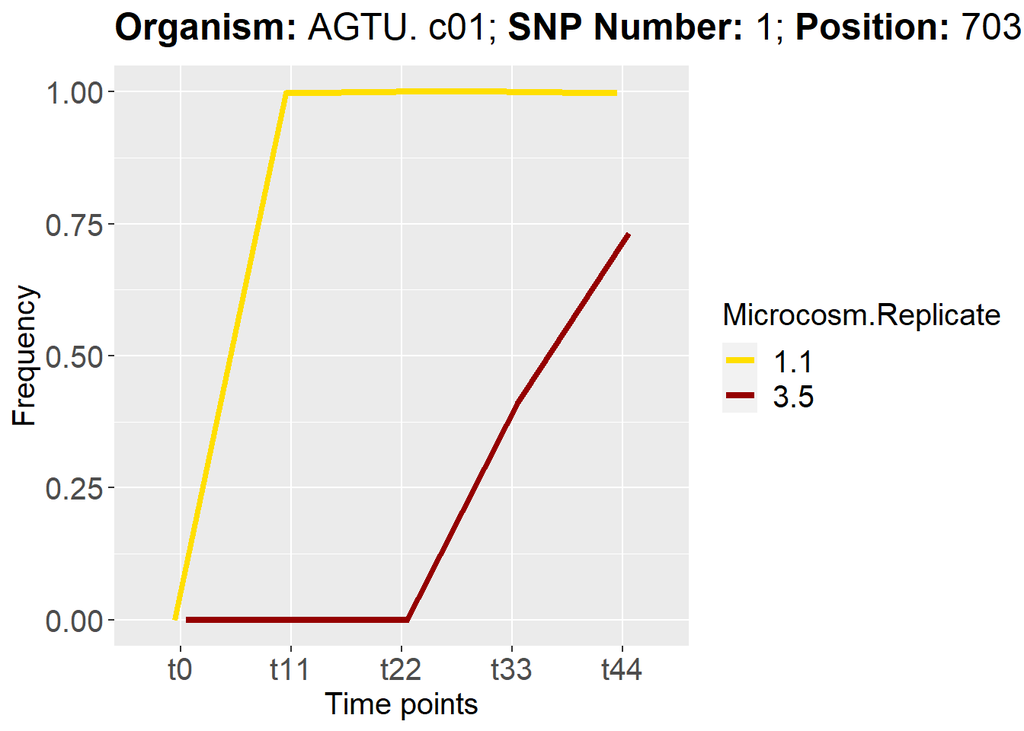

```r
#SNP1
ggplot(SNP1_plot, aes(x = SNP1_time, y = SNP1_frequency, group = SNP1_name, color = SNP1_name)) +
  geom_line(position=position_dodge(width=0.2), cex = 1.5) +
  labs(title = latex2exp::TeX("\\textbf{Organism:} AGTU.c01; \\textbf{SNP Number:} 1; \\textbf{Position:} 703340"),
        x = ("Time points"),
        y = ("Frequency"),
        colour = "Microcosm.Replicate") +
  theme(axis.text = element_text(size = 15),
        axis.title = element_text(size = 15),
        plot.title = element_text(size = 18),
        legend.title = element_text(size = 15),
        legend.text = element_text(size = 15)) +
  #1.1 3.5
  scale_color_manual(values=c("#ffdf00","#950000"))
```

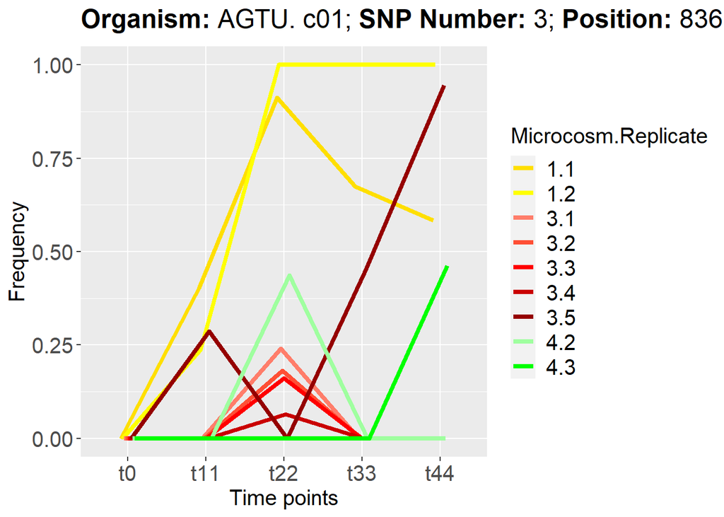

```r
#SNP3
  ggplot(SNP3_plot, aes(x = SNP3_time, y = SNP3_frequency, group = SNP3_name, color = SNP3_name)) +
    geom_line(position=position_dodge(width=0.2), cex = 1.5) +
  labs(title = latex2exp::TeX("\\textbf{Organism:} AGTU.c01; \\textbf{SNP Number:} 3; \\textbf{Position:} 83654"),
        x = ("Time points"),
        y = ("Frequency"),
        colour = "Microcosm.Replicate") +
  theme(axis.text = element_text(size = 15),
        axis.title = element_text(size = 15),
        plot.title = element_text(size = 18),
        legend.title = element_text(size = 15),
        legend.text = element_text(size = 15)) +
    #1.1 1.2 3.1 3.2 3.3 3.4 3.5 4.2 4.3
    scale_color_manual(values=c("#ffdf00", "#ffff00", "#ff7d6a", "#ff4f35", "#ff0000", "#ca0000", "#950000", "#9fff9f", "#00ff00"))
```

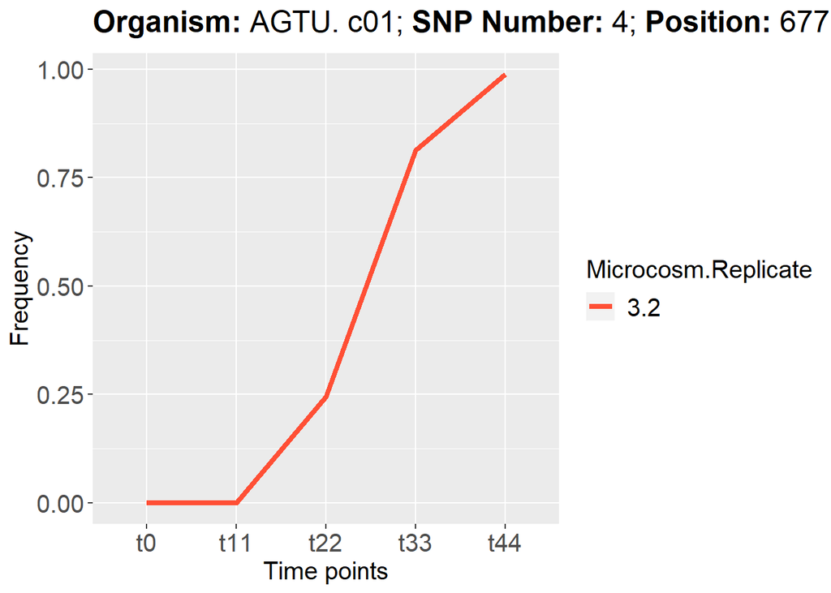

```r
#SNP4
  ggplot(SNP4_plot, aes(x = SNP4_time, y = SNP4_frequency, group = SNP4_name, color = SNP4_name)) +
    geom_line(position=position_dodge(width=0.2), cex = 1.5) +
  labs(title = latex2exp::TeX("\\textbf{Organism:} AGTU.c01; \\textbf{SNP Number:} 4; \\textbf{Position:} 677536"),
        x = ("Time points"),
        y = ("Frequency"),
        colour = "Microcosm.Replicate") +
  theme(axis.text = element_text(size = 15),
        axis.title = element_text(size = 15),
        plot.title = element_text(size = 18),
        legend.title = element_text(size = 15),
        legend.text = element_text(size = 15)) +
    #3.2
    scale_color_manual(values=c("#ff4f35"))
```

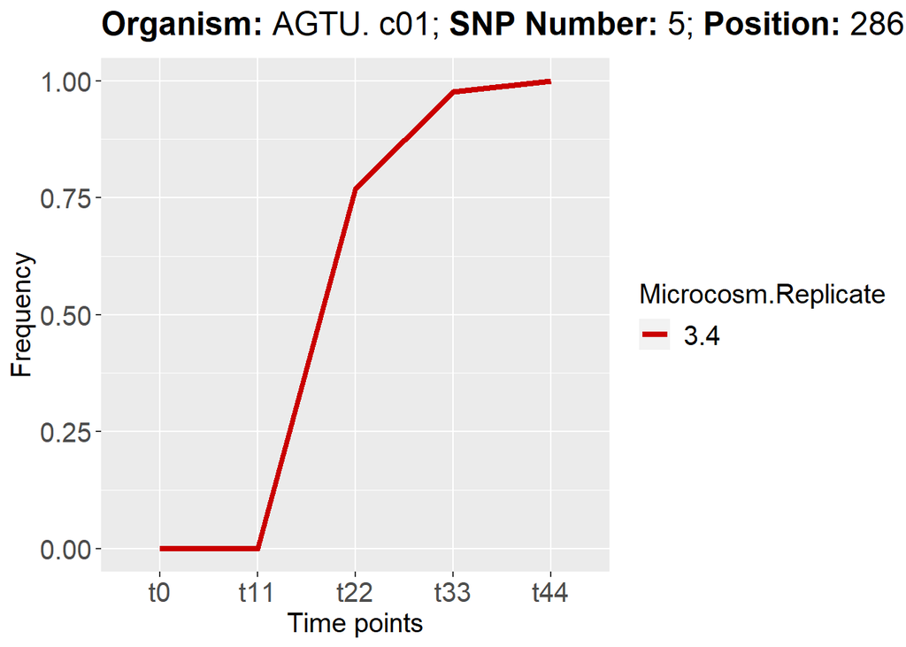

```r
#SNP5
  ggplot(SNP5_plot, aes(x = SNP5_time, y = SNP5_frequency, group = SNP5_name, color = SNP5_name)) +
    geom_line(position=position_dodge(width=0.2), cex = 1.5) +
  labs(title = latex2exp::TeX("\\textbf{Organism:} AGTU.c01; \\textbf{SNP Number:} 5; \\textbf{Position:} 2863371"),
        x = ("Time points"),
        y = ("Frequency"),
        colour = "Microcosm.Replicate") +
    theme(axis.text = element_text(size = 15),
        axis.title = element_text(size = 15),
        plot.title = element_text(size = 18),
        legend.title = element_text(size = 15),
        legend.text = element_text(size = 15)) +
    #3.4
    scale_color_manual(values=c("#ca0000"))
```

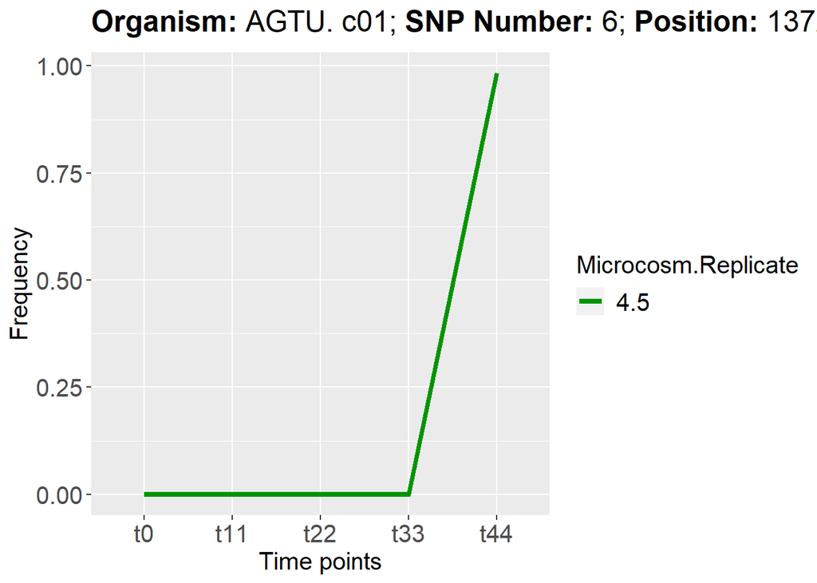

```r
#SNP6
  ggplot(SNP6_plot, aes(x = SNP6_time, y = SNP6_frequency, group = SNP6_name, color = SNP6_name)) +
    geom_line(position=position_dodge(width=0.2), cex = 1.5) +
  labs(title = latex2exp::TeX("\\textbf{Organism:} AGTU.c01; \\textbf{SNP Number:} 6; \\textbf{Position:} 1372439"),
        x = ("Time points"),
        y = ("Frequency"),
        colour = "Microcosm.Replicate") +
    theme(axis.text = element_text(size = 15),
        axis.title = element_text(size = 15),
        plot.title = element_text(size = 18),
        legend.title = element_text(size = 15),
        legend.text = element_text(size = 15)) +
    #4.5
    scale_color_manual(values=c("#009500"))
```

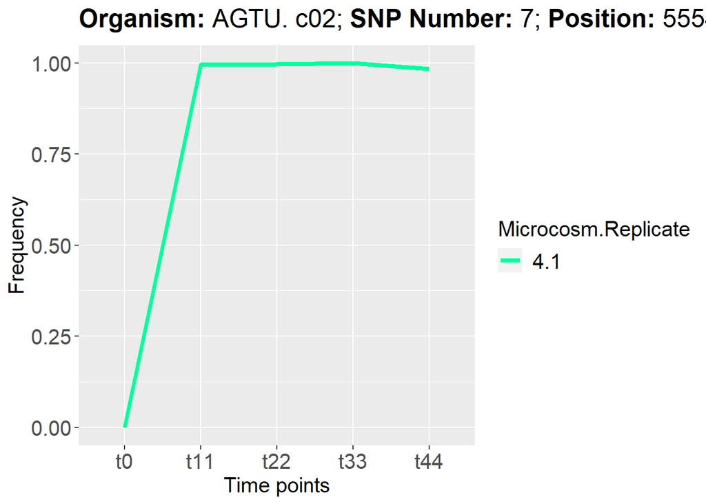

```r
#SNP7
  ggplot(SNP7_plot, aes(x = SNP7_time, y = SNP7_frequency, group = SNP7_name, color = SNP7_name)) +
    geom_line(position=position_dodge(width=0.2), cex = 1.5) +
  labs(title = latex2exp::TeX("\\textbf{Organism:} AGTU.c02; \\textbf{SNP Number:} 7; \\textbf{Position:} 555455"),
        x = ("Time points"),
        y = ("Frequency"),
        colour = "Microcosm.Replicate") +
    theme(axis.text = element_text(size = 15),
        axis.title = element_text(size = 15),
        plot.title = element_text(size = 18),
        legend.title = element_text(size = 15),
        legend.text = element_text(size = 15)) +
    #4.1
    scale_color_manual(values=c("#00ff9f"))
```

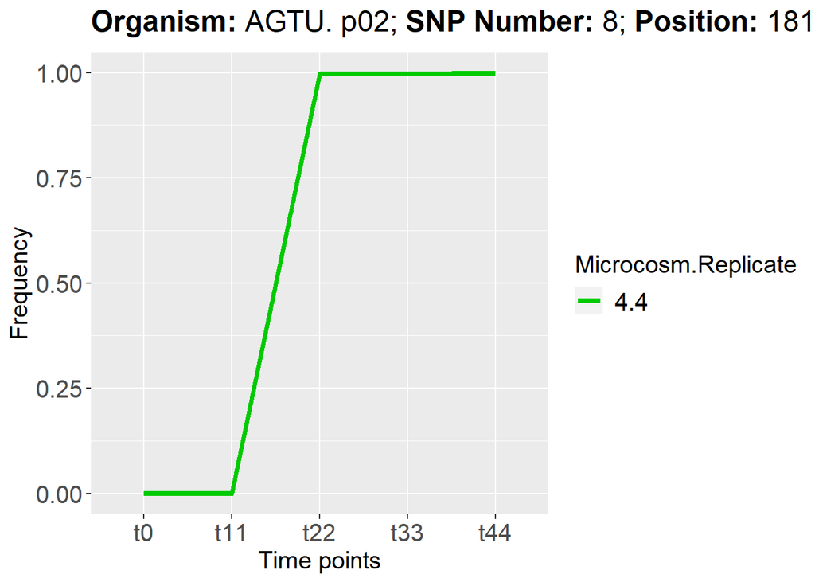

```r
#SNP8
  ggplot(SNP8_plot, aes(x = SNP8_time, y = SNP8_frequency, group = SNP8_name, color = SNP8_name)) +
    geom_line(position=position_dodge(width=0.2), cex = 1.5) +
  labs(title = latex2exp::TeX("\\textbf{Organism:} AGTU.p02; \\textbf{SNP Number:} 8; \\textbf{Position:} 181352"),
        x = ("Time points"),
        y = ("Frequency"),
        colour = "Microcosm.Replicate") +
    theme(axis.text = element_text(size = 15),
        axis.title = element_text(size = 15),
        plot.title = element_text(size = 18),
        legend.title = element_text(size = 15),
        legend.text = element_text(size = 15)) +
    #4.4
    scale_color_manual(values=c("#00ca00"))
```

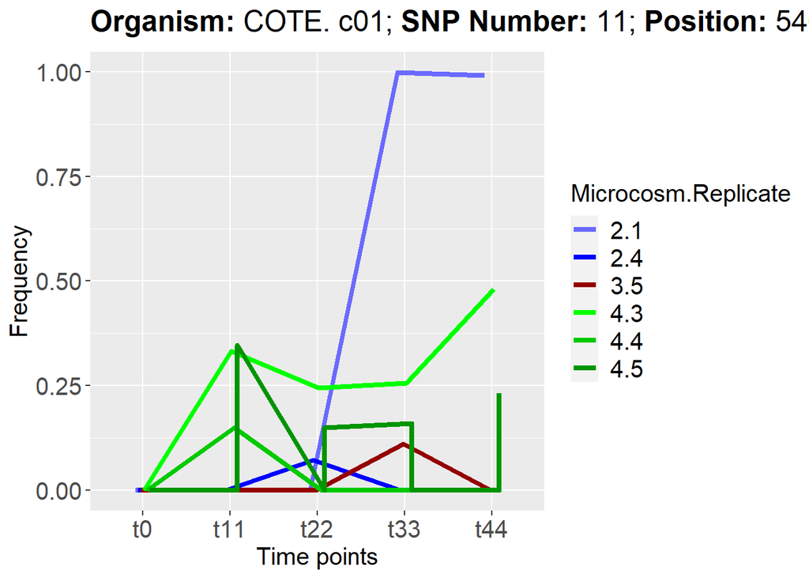

```r
#SNP11
  ggplot(SNP11_plot, aes(x = SNP11_time, y = SNP11_frequency, group = SNP11_name, color = SNP11_name)) +
    geom_line(position=position_dodge(width=0.2), cex = 1.5) +
  labs(title = latex2exp::TeX("\\textbf{Organism:} COTE.c01; \\textbf{SNP Number:} 11; \\textbf{Position:} 5466695"),
        x = ("Time points"),
        y = ("Frequency"),
        colour = "Microcosm.Replicate") +
    theme(axis.text = element_text(size = 15),
        axis.title = element_text(size = 15),
        plot.title = element_text(size = 18),
        legend.title = element_text(size = 15),
        legend.text = element_text(size = 15)) +
    #2.1 2.4 3.5 4.3 4.4 4.5 4.5
    scale_color_manual(values=c("#6a6aff", "#0000ff", "#950000", "#00ff00", "#00ca00", "#009500", "#009500"))
```

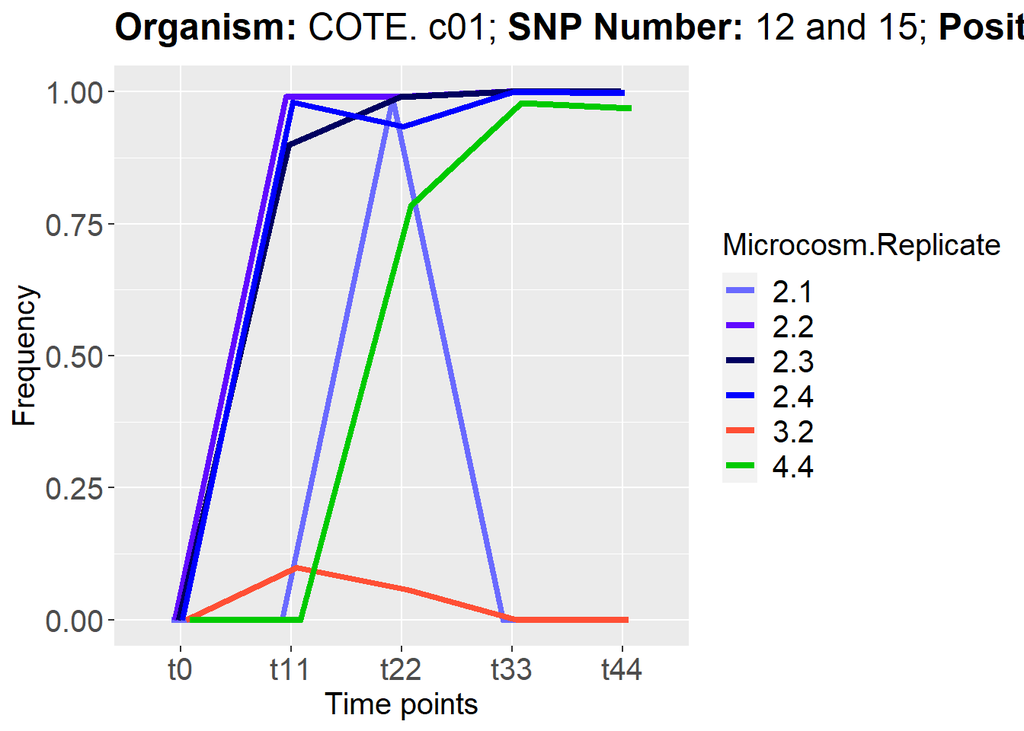

```r
#SNP12_15
  ggplot(SNP12_15_plot, aes(x = SNP12_15_time, y = SNP12_15_frequency, group = SNP12_15_name, color = SNP12_15_name)) +
    geom_line(position=position_dodge(width=0.2), cex = 1.5) +
  labs(title = latex2exp::TeX("\\textbf{Organism:} COTE.c01; \\textbf{SNP Number:} 12 and 15; \\textbf{Position:} 5466897"),
        x = ("Time points"),
        y = ("Frequency"),
        colour = "Microcosm.Replicate") +
    theme(axis.text = element_text(size = 15),
        axis.title = element_text(size = 15),
        plot.title = element_text(size = 18),
        legend.title = element_text(size = 15),
        legend.text = element_text(size = 15)) +
    #2.1 2.2 2.3 2.4 3.2 4.4
    scale_color_manual(values=c("#6a6aff", "#6009ff", "#000060", "#0000ff", "#ff4f35", "#00ca00"))
```

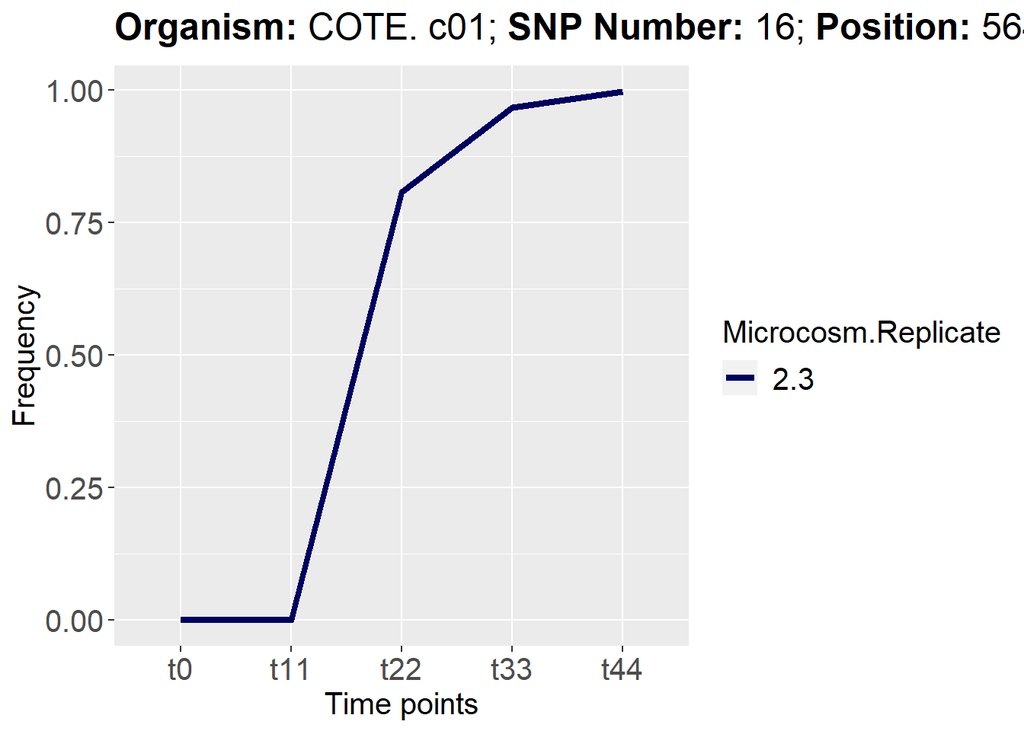

```r
#SNP16
  ggplot(SNP16_plot, aes(x = SNP16_time, y = SNP16_frequency, group = SNP16_name, color = SNP16_name)) +
    geom_line(position=position_dodge(width=0.2), cex = 1.5) +
  labs(title = latex2exp::TeX("\\textbf{Organism:} COTE.c01; \\textbf{SNP Number:} 16; \\textbf{Position:} 5643748"),
        x = ("Time points"),
        y = ("Frequency"),
        colour = "Microcosm.Replicate") +
    theme(axis.text = element_text(size = 15),
        axis.title = element_text(size = 15),
        plot.title = element_text(size = 18),
        legend.title = element_text(size = 15),
        legend.text = element_text(size = 15)) +
    #2.3
    scale_color_manual(values=c("#000060"))
```

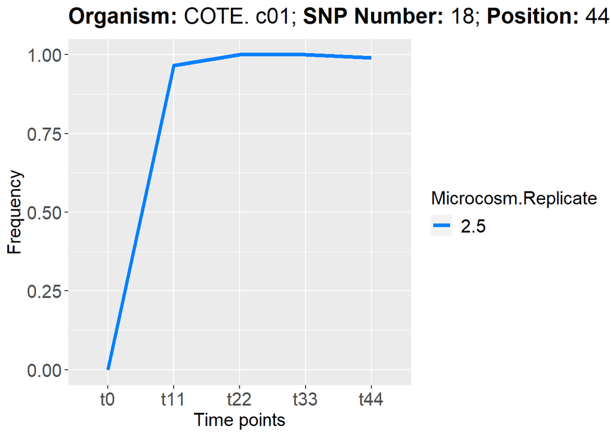

```r
#SNP18
  ggplot(SNP18_plot, aes(x = SNP18_time, y = SNP18_frequency, group = SNP18_name, color = SNP18_name)) +
    geom_line(position=position_dodge(width=0.2), cex = 1.5) +
  labs(title = latex2exp::TeX("\\textbf{Organism:} COTE.c01; \\textbf{SNP Number:} 18; \\textbf{Position:} 4436504"),
        x = ("Time points"),
        y = ("Frequency"),
        colour = "Microcosm.Replicate") +
    theme(axis.text = element_text(size = 15),
        axis.title = element_text(size = 15),
        plot.title = element_text(size = 18),
        legend.title = element_text(size = 15),
        legend.text = element_text(size = 15)) +
    #2.5
    scale_color_manual(values=c("#0080ff"))
```

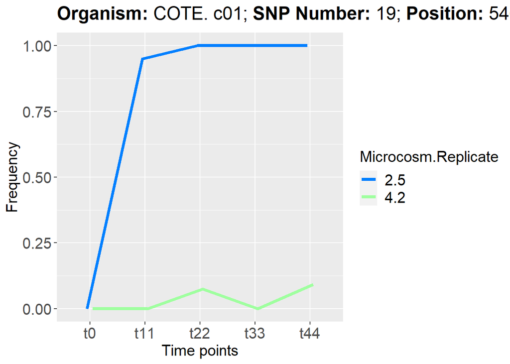

```r
#SNP19
  ggplot(SNP19_plot, aes(x = SNP19_time, y = SNP19_frequency, group = SNP19_name, color = SNP19_name)) +
    geom_line(position=position_dodge(width=0.2), cex = 1.5) +
  labs(title = latex2exp::TeX("\\textbf{Organism:} COTE.c01; \\textbf{SNP Number:} 19; \\textbf{Position:} 5466537"),
        x = ("Time points"),
        y = ("Frequency"),
        colour = "Microcosm.Replicate") +
    theme(axis.text = element_text(size = 15),
        axis.title = element_text(size = 15),
        plot.title = element_text(size = 18),
        legend.title = element_text(size = 15),
        legend.text = element_text(size = 15)) +
    #2.5 4.2
    scale_color_manual(values=c("#0080ff", "#9fff9f"))
```

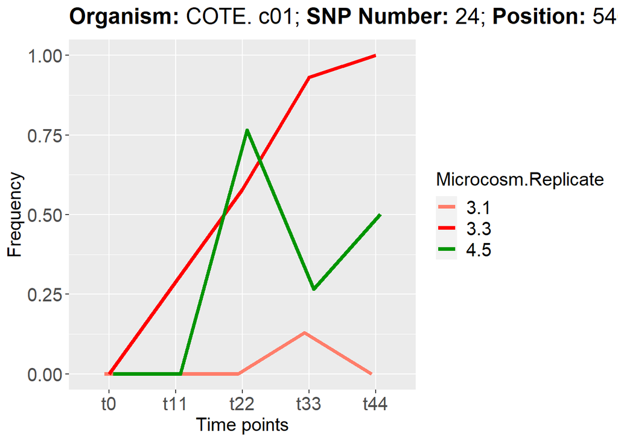

```r
#SNP24
  ggplot(SNP24_plot, aes(x = SNP24_time, y = SNP24_frequency, group = SNP24_name, color = SNP24_name)) +
    geom_line(position=position_dodge(width=0.2), cex = 1.5) +
  labs(title = latex2exp::TeX("\\textbf{Organism:} COTE.c01; \\textbf{SNP Number:} 24; \\textbf{Position:} 5466905"),
        x = ("Time points"),
        y = ("Frequency"),
        colour = "Microcosm.Replicate") +
    theme(axis.text = element_text(size = 15),
        axis.title = element_text(size = 15),
        plot.title = element_text(size = 18),
        legend.title = element_text(size = 15),
        legend.text = element_text(size = 15)) +
    #3.1 3.3 4.5
    scale_color_manual(values=c("#ff7d6a", "#ff0000", "#009500"))
```

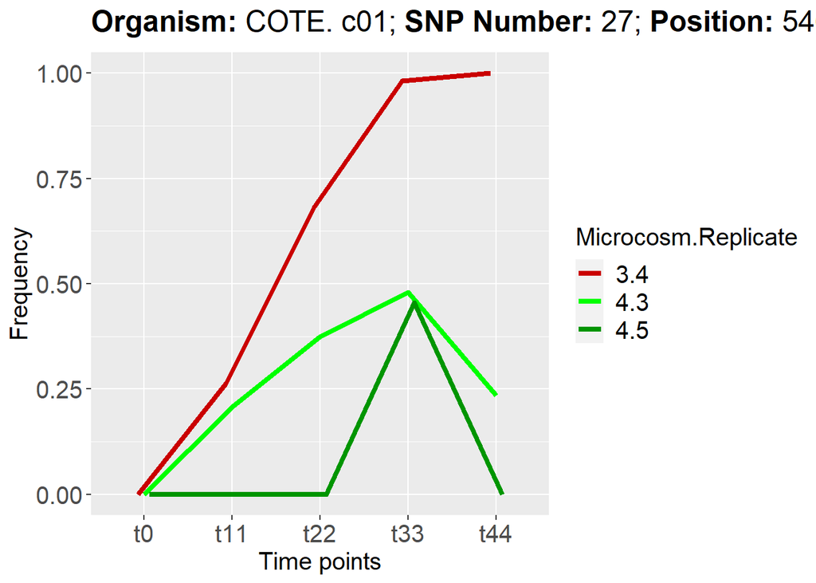

```r
#SNP27
  ggplot(SNP27_plot, aes(x = SNP27_time, y = SNP27_frequency, group = SNP27_name, color = SNP27_name)) +
    geom_line(position=position_dodge(width=0.2), cex = 1.5) +
  labs(title = latex2exp::TeX("\\textbf{Organism:} COTE.c01; \\textbf{SNP Number:} 27; \\textbf{Position:} 5466552"),
        x = ("Time points"),
        y = ("Frequency"),
        colour = "Microcosm.Replicate") +
    theme(axis.text = element_text(size = 15),
        axis.title = element_text(size = 15),
        plot.title = element_text(size = 18),
        legend.title = element_text(size = 15),
        legend.text = element_text(size = 15)) +
    #3.4 4.3 4.5
    scale_color_manual(values=c("#ca0000", "#00ff00", "#009500"))
```

# Question 3

**Can we estimate dN/dS? Which genes are under positive/negative selection?**

## Import data of all SNP

The data of all SNPs with the frequency and NS/S is found in the file *allSNPs_w_gene_position.tsv*.

```r
#Import data files and have a general look at them.
  #!Attention: look at the directory of where the file are stored
  all_SNP <- read.delim(file =  "C:/Users/sabri/OneDrive/Desktop/HS21/Bachelor thesis/Hand in folder/Data/Original/allSNPs_w_gene_position.tsv", header = FALSE)
    colnames(all_SNP) <- c("Cosme.Rep", "Micr.Genom", "Place", "alt", "Gene", "NS/S", "t0", "t1", "t2", "t3", "t4")
    #str(all_SNP)

  SNP_genes_sorted <- read.delim(file = "C:/Users/sabri/OneDrive/Desktop/HS21/Bachelor thesis/Hand in folder/Results/Question 1/Result_Genes_sorted.csv", sep = ",")
    #str(SNP_genes_sorted)
```

## Tidy up data

I have to tidy the data of all SNPs to be able to work with them. Especially I have to change the Micr.Genom for them to fit the SNP_genes_sorted one.

```r
#Get all Micr.Genom and put them in a vector to look if they fit the ones that will be examined
  Microbe_Replicon <- unique(all_SNP$Micr.Genom)

#Changing them to fit the ones from the SNP_genes_sorted
  for (c in 1:nrow(all_SNP)) {
    if(all_SNP[c, 2] == Microbe_Replicon[1]){
      all_SNP[c, 2] <- "AGTU.c01"
    }
    if(all_SNP[c, 2] == Microbe_Replicon[2]){
      all_SNP[c, 2] <- "AGTU.c02"
    }
    if(all_SNP[c, 2] == Microbe_Replicon[3]){
      all_SNP[c, 2] <- "AGTU.p01"
    }
    if(all_SNP[c, 2] == Microbe_Replicon[4]){
      all_SNP[c, 2] <- "AGTU.p02"
    }
    if(all_SNP[c, 2] == Microbe_Replicon[5]){
      all_SNP[c, 2] <- "AGTU.p03"
    }
    if(all_SNP[c, 2] == Microbe_Replicon[6]){
      all_SNP[c, 2] <- "COTE.c01"
    }
    if(all_SNP[c, 2] == Microbe_Replicon[7]){
      all_SNP[c, 2] <- "COTE.c02"
    }
    if(all_SNP[c, 2] == Microbe_Replicon[8]){
      all_SNP[c, 2] <- "OCAN.c01"
    }
    if(all_SNP[c, 2] == Microbe_Replicon[9]){
      all_SNP[c, 2] <- "OCAN.c02"
    }
    if(all_SNP[c, 2] == Microbe_Replicon[10]){
      all_SNP[c, 2] <- "MISA.c01"
    }
  }

#Check the new Micr.Genom
  Microbe_Replicon_new <- unique(all_SNP$Micr.Genom)
```

## Find SNP place

In the all_SNP I want to find all SNPs that are in the same position as the fixed ones found in genes.

```r
#Get the positions that will be looked for
  SNP_Position <- as.character(unique(SNP_genes_sorted$x.Position))

#Split the table into the positions and make a list of the new tables
  all_SNP_Place <- split(all_SNP, all_SNP$Place)[SNP_Position]
```

## Finde Genes

```r
#Finding the gene tags of the fixed SNPs
  Genes <- c()
    for (i in 1:length(all_SNP_Place)) {
      temp_gene <- unique(all_SNP_Place[[i]][["Gene"]])
      Genes <- c(Genes, temp_gene)
    }
  #There are dublicates in there because some fixed SNPs are in the same gene
    Genes_which <- which(duplicated(Genes))
    Genes_unique <- unique(Genes)
    Genes_unique <- Genes_unique[-2]

#Split and select only the genes of the fixed SNPs from all SNP data
  all_SNP_Genes <- split(all_SNP, all_SNP$Gene)[Genes]
```

### Tidy up data again

Now I need to tidy up the list of the tables

```r
#AGTU is not present in microcosm 2, so we delet these SNPs for further analysis
  all_SNP_Genes[["AGTU001.0001.c01_006770"]] <- all_SNP_Genes[["AGTU001.0001.c01_006770"]][-c(2, 3), ]
  all_SNP_Genes[["AGTU001.0001.c01_000790"]] <- all_SNP_Genes[["AGTU001.0001.c01_000790"]][-c(3), ]
  all_SNP_Genes[["AGTU001.0001.c01_027410"]] <- all_SNP_Genes[["AGTU001.0001.c01_027410"]][-c(2, 3), ]
#OCAN is only present in microcosm 4, the others are deleted
  all_SNP_Genes[["OCAN001.0001.c02_020540"]] <- all_SNP_Genes[["OCAN001.0001.c02_020540"]][c(-1),]

all_SNP_Genes[Genes_which] <- NULL
```

### Save Gene data

```r
#The files should include the number of the SNP, for this we need a vector with the numbers now with the MISA and OCAN data
SNP_number <- c("1", "3", "4", "5", "6", "7", "8", "11_12_15_19_24_27", "16", "18", "30", "31", "32", "33", "34", "38_39_40_41")

#store the results !Attention: look at the directory of where the file will be stored
  #for (j in 1:length(all_SNP_Genes)) {
    #file_name <- paste0("Gene_to_SNP", SNP_number[j] ,".csv")
    #write.csv(all_SNP_Genes[j], file = file_name)
  #}
```

## dN/dS calculation

I calculate dN/dS per microcosm.

```r
#I only distinguish between the microcosm and not the replicate. So first I have to change the microcosm.replicate to only the microcosm number.
  for (k in 1:length(all_SNP_Genes)) {
    for (l in 1:nrow(all_SNP_Genes[[k]])) {
      if (all_SNP_Genes[[k]][["Cosme.Rep"]][l] == 1.1)  {all_SNP_Genes[[k]][["Cosme.Rep"]][l] <- 1}
      if (all_SNP_Genes[[k]][["Cosme.Rep"]][l] == 1.2)  {all_SNP_Genes[[k]][["Cosme.Rep"]][l] <- 1}

      if (all_SNP_Genes[[k]][["Cosme.Rep"]][l] == 2.1)  {all_SNP_Genes[[k]][["Cosme.Rep"]][l] <- 2}
      if (all_SNP_Genes[[k]][["Cosme.Rep"]][l] == 2.2)  {all_SNP_Genes[[k]][["Cosme.Rep"]][l] <- 2}
      if (all_SNP_Genes[[k]][["Cosme.Rep"]][l] == 2.3)  {all_SNP_Genes[[k]][["Cosme.Rep"]][l] <- 2}
      if (all_SNP_Genes[[k]][["Cosme.Rep"]][l] == 2.4)  {all_SNP_Genes[[k]][["Cosme.Rep"]][l] <- 2}
      if (all_SNP_Genes[[k]][["Cosme.Rep"]][l] == 2.5)  {all_SNP_Genes[[k]][["Cosme.Rep"]][l] <- 2}

      if (all_SNP_Genes[[k]][["Cosme.Rep"]][l] == 3.1)  {all_SNP_Genes[[k]][["Cosme.Rep"]][l] <- 3}
      if (all_SNP_Genes[[k]][["Cosme.Rep"]][l] == 3.2)  {all_SNP_Genes[[k]][["Cosme.Rep"]][l] <- 3}
      if (all_SNP_Genes[[k]][["Cosme.Rep"]][l] == 3.3)  {all_SNP_Genes[[k]][["Cosme.Rep"]][l] <- 3}
      if (all_SNP_Genes[[k]][["Cosme.Rep"]][l] == 3.4)  {all_SNP_Genes[[k]][["Cosme.Rep"]][l] <- 3}
      if (all_SNP_Genes[[k]][["Cosme.Rep"]][l] == 3.5)  {all_SNP_Genes[[k]][["Cosme.Rep"]][l] <- 3}

      if (all_SNP_Genes[[k]][["Cosme.Rep"]][l] == 4.1)  {all_SNP_Genes[[k]][["Cosme.Rep"]][l] <- 4}
      if (all_SNP_Genes[[k]][["Cosme.Rep"]][l] == 4.2)  {all_SNP_Genes[[k]][["Cosme.Rep"]][l] <- 4}
      if (all_SNP_Genes[[k]][["Cosme.Rep"]][l] == 4.3)  {all_SNP_Genes[[k]][["Cosme.Rep"]][l] <- 4}
      if (all_SNP_Genes[[k]][["Cosme.Rep"]][l] == 4.4)  {all_SNP_Genes[[k]][["Cosme.Rep"]][l] <- 4}
      if (all_SNP_Genes[[k]][["Cosme.Rep"]][l] == 4.5)  {all_SNP_Genes[[k]][["Cosme.Rep"]][l] <- 4}
    }
  }

  #Splitting the item on the list into a list for the microcosms
    for (m in 1:length(all_SNP_Genes)) {
      all_SNP_Genes[[m]] <- split(all_SNP_Genes[[m]], all_SNP_Genes[[m]][1])
    }


  #Calculating dN/dS
    Result_dNdS_microcosm <- as.data.frame(c())

    for (n in 1:length(all_SNP_Genes)) {
      for (o in 1:length(all_SNP_Genes[[n]])) {
        temp_SNP_count_NS <- 0
        temp_SNP_count_S <- 0
        temp_Result_dNdS_microcosm <- c()

        for (p in 1:nrow(all_SNP_Genes[[n]][[o]])) {
          if (all_SNP_Genes[[n]][[o]][["NS/S"]][p] == "NS") {
            temp_SNP_count_NS <- temp_SNP_count_NS + 1
          } else if (all_SNP_Genes[[n]][[o]][["NS/S"]][p] == "S") {
            temp_SNP_count_S <- temp_SNP_count_S + 1}
          if (temp_SNP_count_S == 0) {
            temp_SNP_dNdS <- NA
          } else if (temp_SNP_count_NS == 0) {
            temp_SNP_dNdS <- NA
          } else {temp_SNP_dNdS <- temp_SNP_count_NS / temp_SNP_count_S}
          temp_Result_dNdS_microcosm <- c(temp_SNP_count_NS, temp_SNP_count_S, temp_SNP_dNdS, names(all_SNP_Genes[[n]][o]), names(all_SNP_Genes[n]))}
        Result_dNdS_microcosm <- rbind(Result_dNdS_microcosm, temp_Result_dNdS_microcosm)
        colnames(Result_dNdS_microcosm) <- c("count_NS", "count_S", "dNdS", "rep", "Gene")}
    }


  #store the results !Attention: look at the directory of where the file will be stored
    #write.csv(Result_dNdS_microcosm, file = "Result_dNdS_microcosm.csv", row.names=FALSE)
```